# Interpréter les modèles de Machine Learning

Valentin Constant

14/10/2021

## Analyse de l’influence des variables sur le sous-dosage.

Les deux packages suivants vont nous servir à interpréter les forêts aléatoires par le biais des courbes ALE et des SHAP values.

Explication de la méthode : https://christophm.github.io/interpretable-ml-book/shapley.html

Explication du code : https://cran.r-project.org/web/packages/iml/vignettes/intro.html

Ce travail repose en majeure partie sur le package IML (pour Interpretable Machine Learning).

```r
set.seed(42)
library("iml")
library("randomForest")
```

#### L’import de la base et la spécification des types de variables.

Si on ne spécifie pas la nature des variables, R pense que chaque variable est quantitative.

*INT* => variable numérique d’entiers

*Pres_germe, continue, enterobactéries, Proba, cefe* = variable factorielle

*Bwt, Bw, PNAm, BiliC, Schwartz, ALAT, DSTD, CRP, PNN, taille* = variable numérique de nombre réels

```r
library(readr)
df <- read_csv("base_xv.csv", col_types = cols(
  INT = col_integer(),
  Pres_germe = col_factor(),
  continue = col_factor(),
  BWt = col_double(),
  BW = col_double(),
  cefe = col_factor(),
  enterobacteries = col_factor(),
  PNAm = col_double(),
  BiliC = col_double(),
  Schwartz = col_double(),
  ALAT = col_double(),
  DSTD = col_double(),
  CRP = col_double(),
  PNN = col_double(),
  taille = col_double(),
  Proba = col_factor()
) )
```

#### Le modèle utilisé : la forêt aléatoire (CART)

Forêt de 50 arbres. Ici la question n’est pas d’optimiser la forêt mais de comprendre son fonctionnement interne.

```r
rf <- randomForest(Proba ~ ., data = df, ntree = 50)
```

#### Utilisation du prédicteur. Début de l’interprétation.

Cette méthode est agnostique, elle est applicable de façon indépendante au modèle.

Elle pourrait s’appliquer à la régression logistique, ou au SVM par exemple.

Ici nous l’appliquons aux forêts aléatoires qui marchent bien sur notre jeu de données et qui ont servi à sélectionner les 15 variables (voir travaux précédents).

```r
X <- df[which(names(df) != "Proba")]
predictor <- Predictor$new(rf, data = X, y = df$Proba)
```

#### Mesure sur l’importance des variables.

A contrario, si on observe la taille, en permutant la taille d’un patient par une autre valeur, cela n’entraine pas un grand nombre d’erreur.

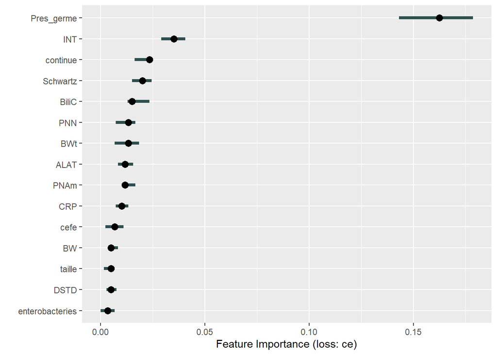

```r
imp <- FeatureImp$new(predictor, loss = "ce", compare = "difference", n.repetitions = 15)
library("ggplot2")
plot(imp)
```

```r
imp$results
```

```
##            feature importance.05  importance importance.95 permutation.error
## 1       Pres_germe   0.143216080 0.162479062   0.178559464       0.162479062
## 2              INT   0.029145729 0.035175879   0.040703518       0.035175879
## 3         continue   0.016247906 0.023450586   0.025125628       0.023450586
## 4         Schwartz   0.015075377 0.020100503   0.024455611       0.020100503
## 5            BiliC   0.012897822 0.015075377   0.023450586       0.015075377
## 6              BWt   0.006700168 0.013400335   0.018425461       0.013400335
## 7              PNN   0.007370184 0.013400335   0.016750419       0.013400335
## 8             PNAm   0.010050251 0.011725293   0.016750419       0.011725293
## 9             ALAT   0.008375209 0.011725293   0.015577889       0.011725293
## 10             CRP   0.007370184 0.010050251   0.013400335       0.010050251
## 11            cefe   0.002345059 0.006700168   0.011055276       0.006700168
## 12            DSTD   0.002847571 0.005025126   0.007705193       0.005025126
## 13          taille   0.001675042 0.005025126   0.006700168       0.005025126
## 14              BW   0.004522613 0.005025126   0.008375209       0.005025126
## 15 enterobacteries   0.000000000 0.003350084   0.006700168       0.003350084
```

#### Effets des variables sur la variable Proba

A présent nous allons étudier non plus l’importance des variables, mais **l’effet des variables sur le sous-dosage.** Nous allons passer en revue individuellement les 15 variables.

##### Explication du graphique de ALE (Accumulated local effects):

Il montre les effets locaux cumulés (ALE) pour la variable en question.

Cette métrique montre comment la prédiction change localement, donc à chaque dosage, lorsque la caractéristique en question voit sa valeur modifiée. Les marques sur l’axe des x indiquent la distribution de la caractéristique (plage de valeur), montrant à quelle intervalle de valeur une région est pertinente pour l’interprétation.

#### Variable la plus importante : Pres_germe

En somme, l’absence du germe permet à la forêt aléatoire de prédire une absence de sous-dosage. Au contraire, la présence du germe a tendance à déboucher sur la prédiction d’un sous-dosage.

Cependant on remarque que la corrélation entre “absence d’un germe et absence d’un sous-dosage” est plus forte que la corrélation entre “présence du germe et présence du sous-dosage”.

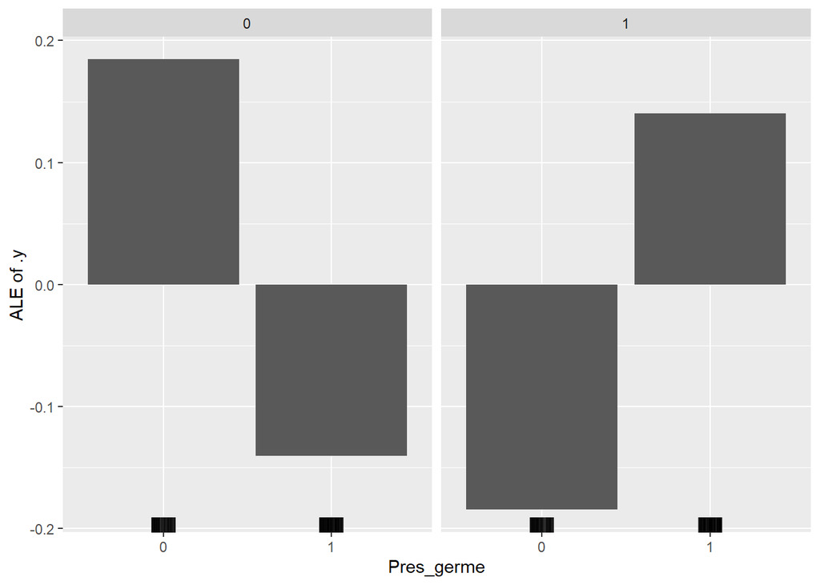

```r
ale <- FeatureEffect$new(predictor, feature = "Pres_germe")
ale$plot()
```

#### 2ème Variable la plus importante : INT

Une durée courte d’intervalle de dose (6 heures) est corrélée à une absence de sous-dosage. (≃0.04 pour 6h)

A l’inverse, plus la durée d’intervalle de dose est élevée (8,12,24 heures), plus les sous-dosage augmentent. (≃0.025 à 0.035)

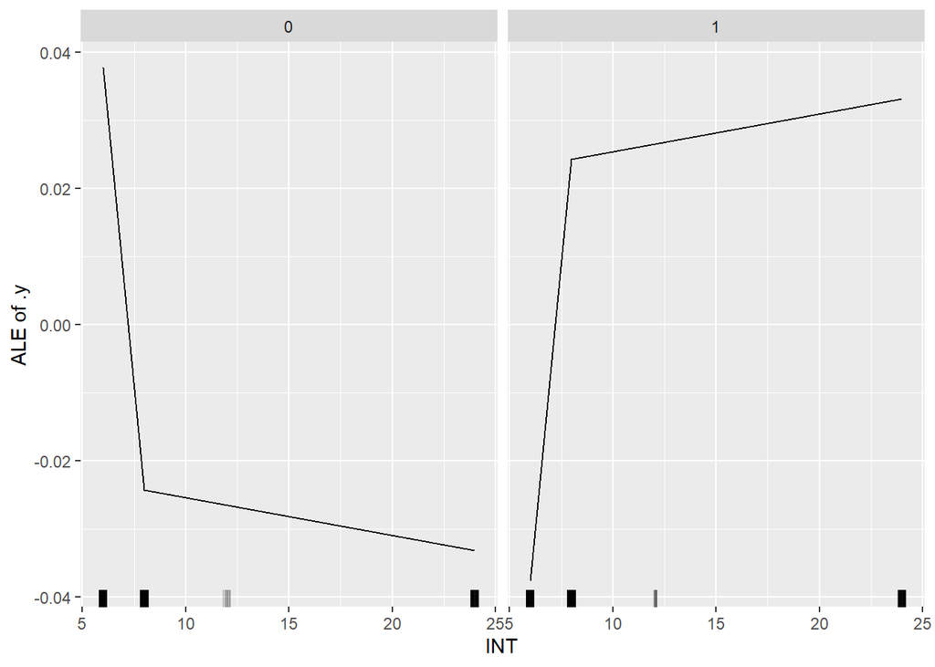

```r
ale <- FeatureEffect$new(predictor, feature = "INT")
ale$plot()
```

#### 3ème Variable la plus importante : continue

Cette variable indique si c’est la dose a été administrée de façon continue ou non.

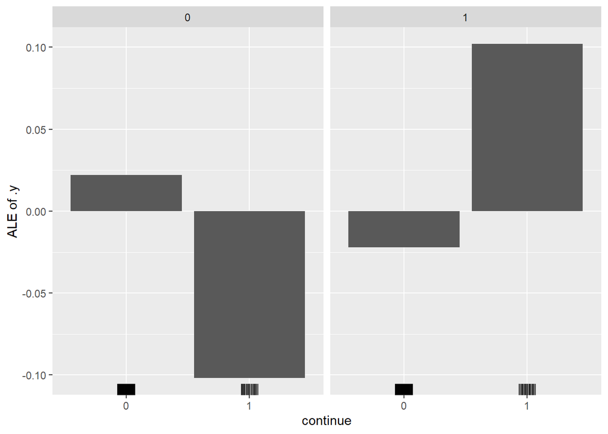

```r
ale <- FeatureEffect$new(predictor, feature = "continue")
ale$plot()
```

#### 4ème Variable la plus importante : Schwartz

Cette variable renvoie à la créatinémie du patient (indice de Schwartz).

Nous obtenons ici cette courbe :

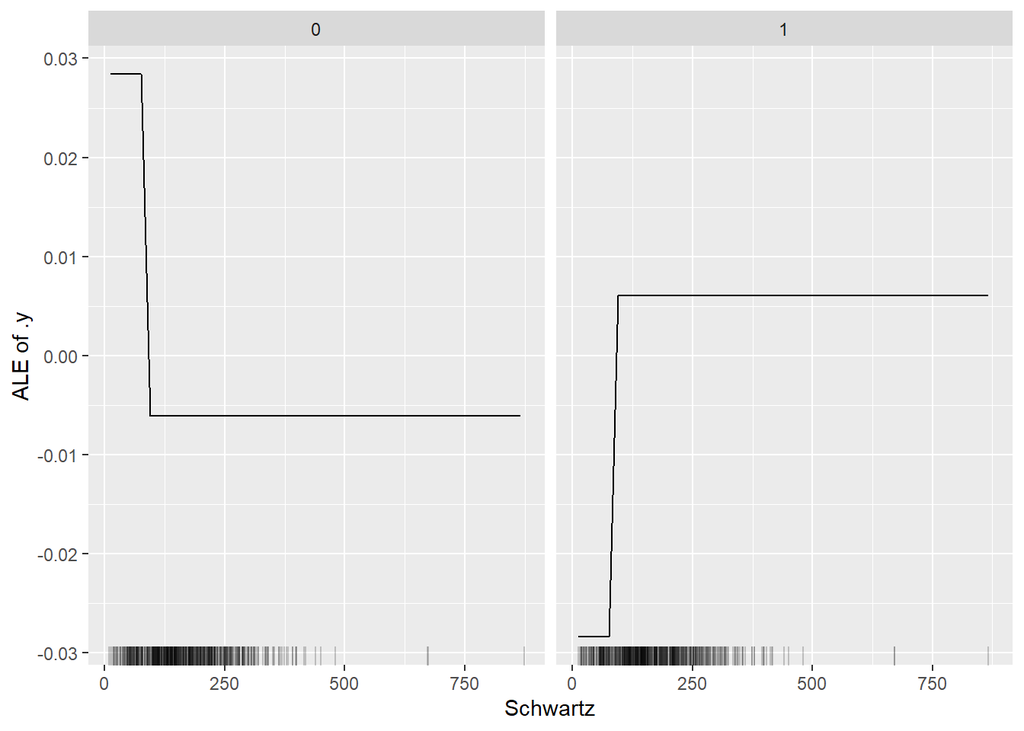

```r
ale <- FeatureEffect$new(predictor, feature = "Schwartz")
ale$plot()
```

#### 5ème Variable la plus importante : BiliC (bilirubine conjuguée)

La bilirubine conjuguée a un effet croissant sur le sous-dosage.

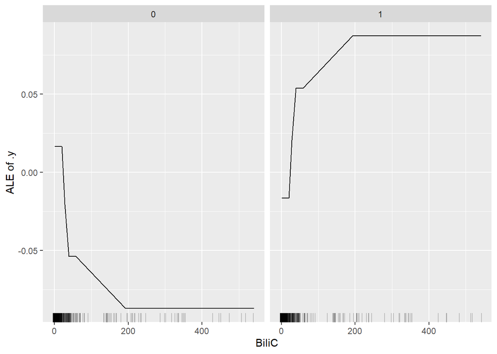

```r
ale <- FeatureEffect$new(predictor, feature = "BiliC")
ale$plot()
```

Même problème que pour ALAT : des valeurs extrêmes faussent le graphique et le rendent difficilement interprétable.

Sous-analyse avec intervalle restreint semble de mise pour mieux comprendre l’effet de l’âge sur le sous-dosage.

La distribution est plus équilibrée mais reste concentrée sur 0 à 25 mois.

Dès les premiers mois (3,4), l’effet est sur le sous-dosage : l’âge l’impacte à une valeur de 0.005 (très faible, et reste constant).

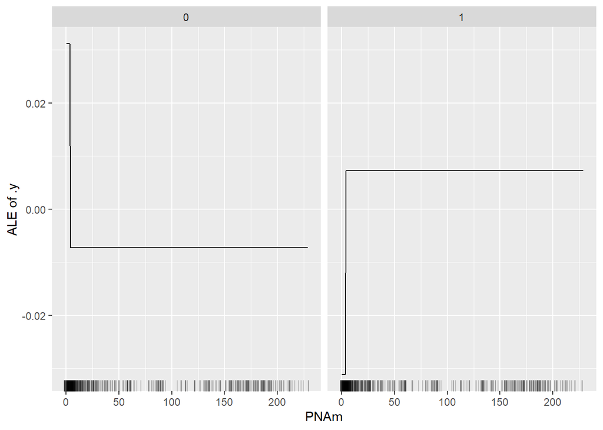

```r
ale <- FeatureEffect$new(predictor, feature = "PNAm",  grid.size = 25)
ale$plot()
```

La faiblesse de cette analyse est lorsque les plages de valeurs sont très éparpillées.

- Une valeur extrême de ALAT à + de 7000 rend le graphique difficilement interprétable.
- Une sous-analyse en restreignant les bornes de l’intervalle de valeur pourrait être menée.

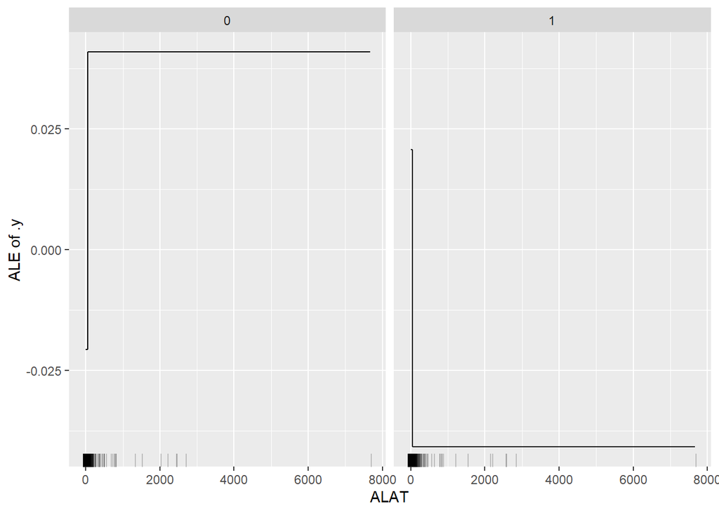

```r
ale <- FeatureEffect$new(predictor, feature = "ALAT", grid.size = 10)
ale$plot()
```

Cette variable indique le nombre de polynucléaire neutrophile dans le sang.

- La majorité de la distribution de la variable est concentrée dans l’intervalle [0;15000].
- Sur cette plage, la variable n’a pas d’effet sur le sous-dosage (≃0.03 à 0) de 0 à 3000.

La variable PNN a qu’un effet sur le sous-dosage que lorsqu’elle prend des valeurs élevée :

- à partir de 3 000, la variable commence à avoir un effet sur le sous-dosage, qui croit jusqu’à atteindre ≃0.01.
- Il reste constant devant le nombre très faible d’observation dans les hautes valeurs.

Généralement, cette variable a un effet relativement faible.

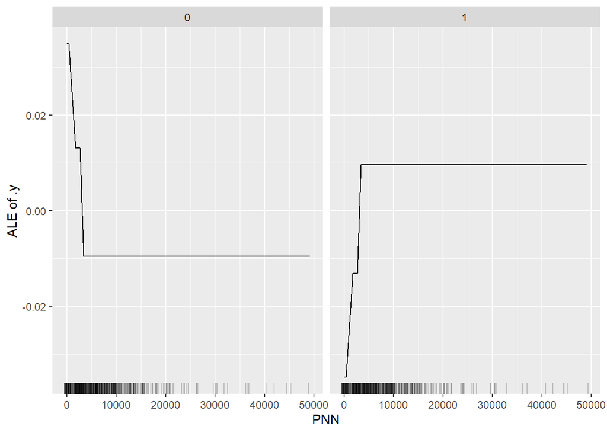

```r
ale <- FeatureEffect$new(predictor, feature = "PNN", grid.size = 12)
ale$plot()
```

- Pour BWt ∈ [0;10], l’impact est positif sur l’absence de sous-dosage. Il décroit plus le poids augmente. L’effet commence à 0.06 pour des valeurs proche de 0 puis diminue rapidement et s’annule vers 10.
- Pour BWt ∈ [10;80], la courbe s’inverse et l’effet est positif sur le sous-dosage.

**Conclusion :** Un poids élevé va entraîner un sous-dosage tandis qu’un poids entre 0 et 10 impactera l’absence de sous-dosage.

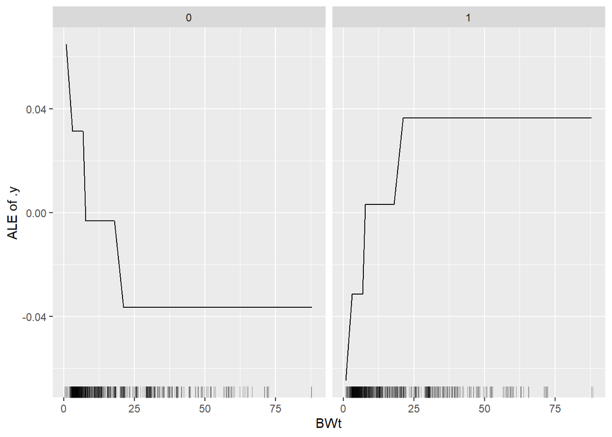

```r
ale <- FeatureEffect$new(predictor, feature = "BWt")
ale$plot()
```

#### 10ème Variable la plus importante : CRP (Protéine Réactive C)

La distribution est concentré dans l’intervalle [0;100].

- Dans cette intervalle, CRP a un effet faible sur la prédiction (constante à ≃0.012).
- En dehors, soit pour CRP ∈ [100;500], la CRP a un impact positif sur le sous-dosage.

En conséquence, Une faible CRP a donc un effet positif sur l’absence de sous-dosage.

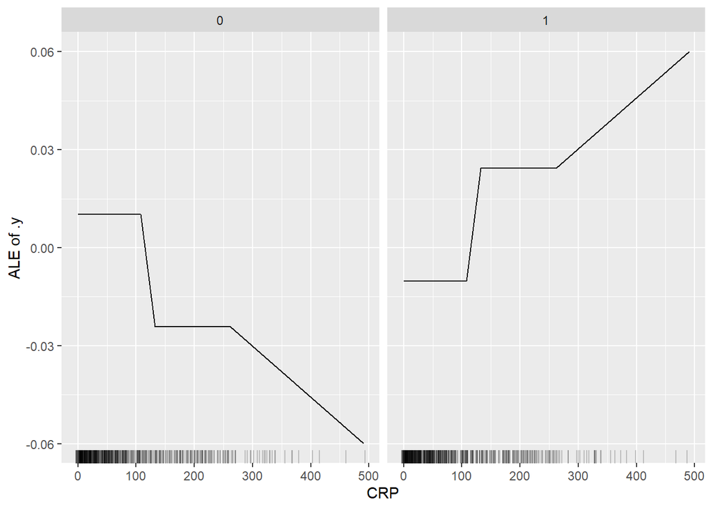

```r
ale <- FeatureEffect$new(predictor, feature = "CRP")
ale$plot()
```

En somme, cette variable est difficilement interprétable et ne fournit que peu de renseignement.

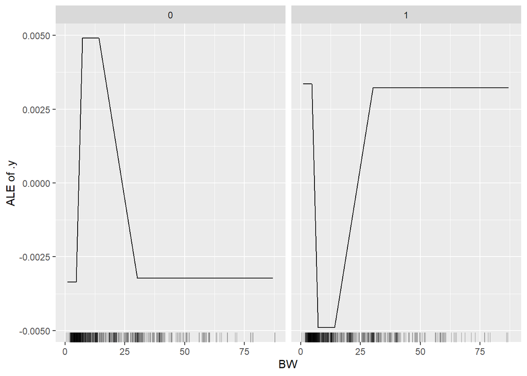

```r
ale <- FeatureEffect$new(predictor, feature = "BW",  grid.size = 5)
ale$plot()
```

Cette variable indique si c’est la céfépime qui a été utilisée lors du dosage.

- On voit que l’absence de céfépime (cefe = 0) a un impact positif sur l’absence de sous-dosage, mais que cette impact est modéré et pas très élevé.
- La présence du céfépime (cefe = 1) a un impact négatif sur l’absence d’un sous-dosage.

En somme, la présence de céfépime permet à la forêt de prédire un sous-dosage (≃0.012). Au contraire, l’absence de céfépime a légère tendance à déboucher sur la prédiction d’un normodosage, mais cela peut être considéré comme étant “neutre” (≃0.004).

La corrélation entre “présence de céfépime et présence du sous-dosage” est 3 fois plus forte (0.012) que la corrélation entre “absence de céfépime et absence du sous-dosage” qui est de 0.004. Cependant les effets sont très faibles.

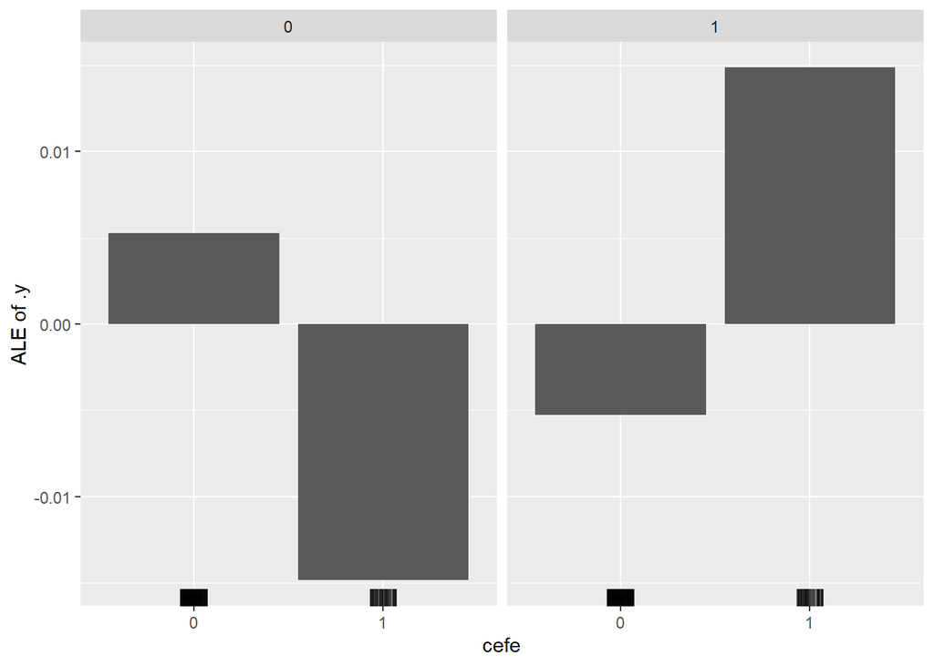

```r
ale <- FeatureEffect$new(predictor, feature = "cefe")
ale$plot()
```

#### 13ème Variable la plus importante : taille

La taille n’a qu’un très faible impacte sur l’absence de sous-dosage (0.005).

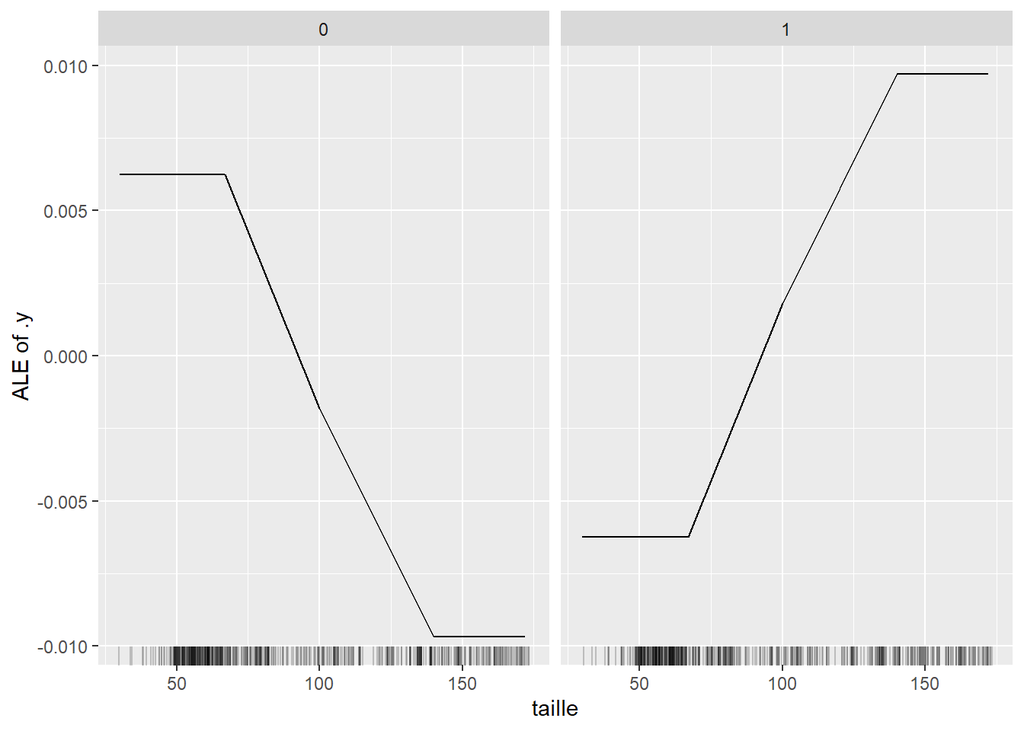

```r
ale <- FeatureEffect$new(predictor, feature = "taille", grid.size = 5)
ale$plot()
```

Cette variable indique la dose administrée.

- Lorsque DSTD ∈ [0; 0,8] => La dose a un effet sur l’absence de sous-dosage a hauteur de ≃0.03 de moyenne.
- Lorsque DSTD ∈ [0,8; 2] => La dose a un effet sur le sous-dosage plafonné à ≃0.015.

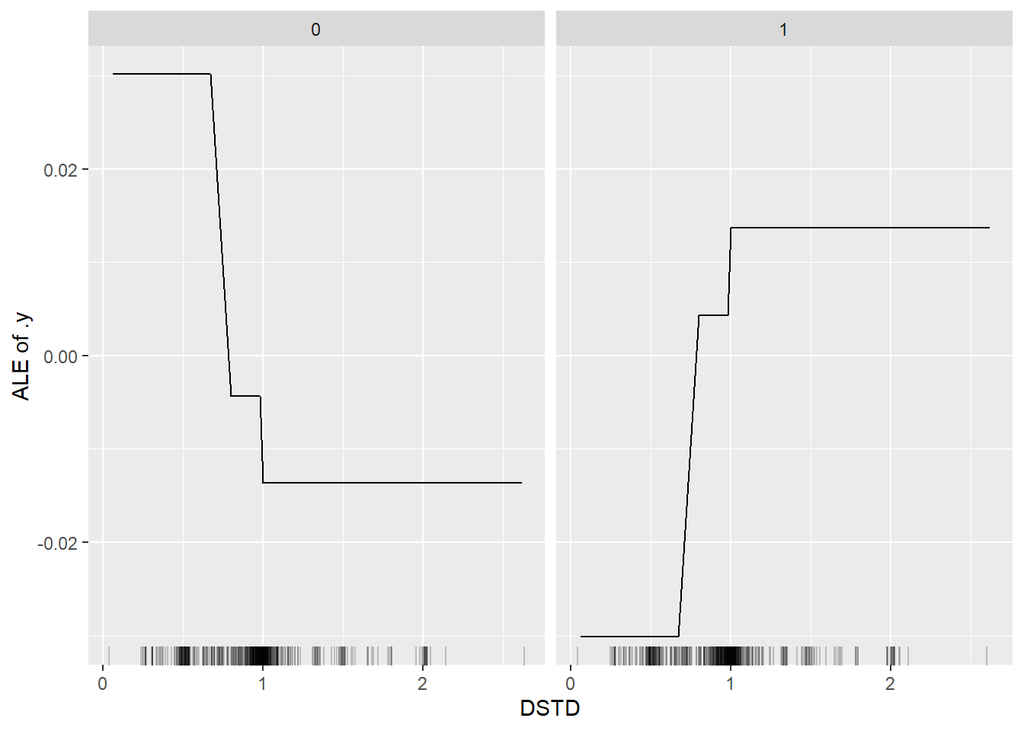

```r
ale <- FeatureEffect$new(predictor, feature = "DSTD")
ale$plot()
```

#### 15ème Variable la plus importante : enterobacteries

[figure not shown]

```r
ale <- FeatureEffect$new(predictor, feature = "enterobacteries", grid.size = 5)
ale$plot()
```

# Analyse locale avec les valeurs de Shapley.

Après une analyse globale des variables sur tout l’ensemble des données, nous allons tenter d’interpréter les prédictions localement, avec l’exemple de 2 dosages.

Le package ‘patchwork’ est requis pour la suite.

```
install.packages('patchwork')
```

```r
library("patchwork")
```

Contrairement aux courbes ALE, les SHAP values vont permettre d’interpréter la prédiction d’un dosage précis. Par exemple, nous allons appliquer cela au premier et deuxième dosage de notre base.

- A gauche vous pouvez observer les valeurs de chaque variable.
- A droite vous avez deux graphiques qui montre l’effet de chaque valeur sur la prédiction.

### Analyse de l’effet des variables du dosage 1 sur le sous-dosage :

Comment interpréter le tableau de valeurs ? Phi = Shapley value (voir définition mathématique, lié à la théorie des jeux)

Valeur réelle : Proba = 0

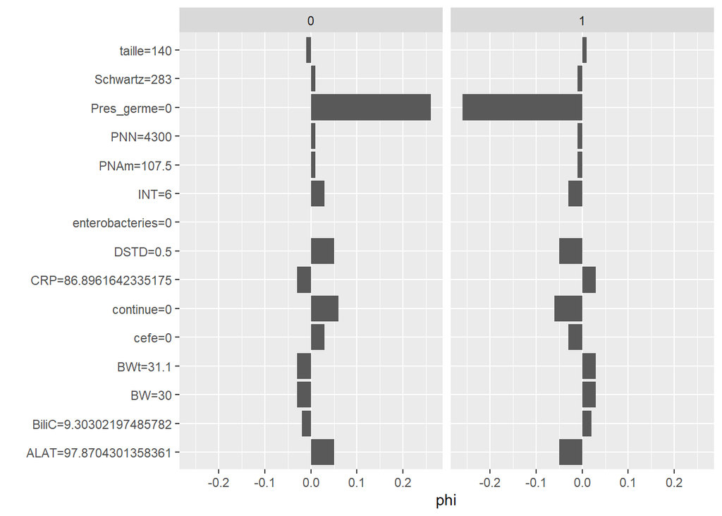

```r
shapley <- Shapley$new(predictor, x.interest = X[1, ])
shapley$plot()
```

```r
head(shapley$results, n=15)
```

```
##            feature class   phi    phi.var          feature.value
## 1             cefe     0  0.03 0.02939394                 cefe=0
## 2             DSTD     0  0.05 0.04797980               DSTD=0.5
## 3         continue     0  0.06 0.05696970             continue=0
## 4              INT     0  0.03 0.04959596                  INT=6
## 5             PNAm     0  0.01 0.01000000             PNAm=107.5
## 6           taille     0 -0.01 0.03020202             taille=140
## 7               BW     0 -0.03 0.02939394                  BW=30
## 8              BWt     0 -0.03 0.02939394               BWt=31.1
## 9              CRP     0 -0.03 0.02939394   CRP=86.8961642335175
## 10             PNN     0  0.01 0.03020202               PNN=4300
## 11            ALAT     0  0.05 0.04797980  ALAT=97.8704301358361
## 12           BiliC     0 -0.02 0.06020202 BiliC=9.30302197485782
## 13        Schwartz     0  0.01 0.03020202           Schwartz=283
## 14      Pres_germe     0  0.26 0.19434343           Pres_germe=0
## 15 enterobacteries     0  0.00 0.02020202      enterobacteries=0
```

Valeur réelle : Proba = 0.

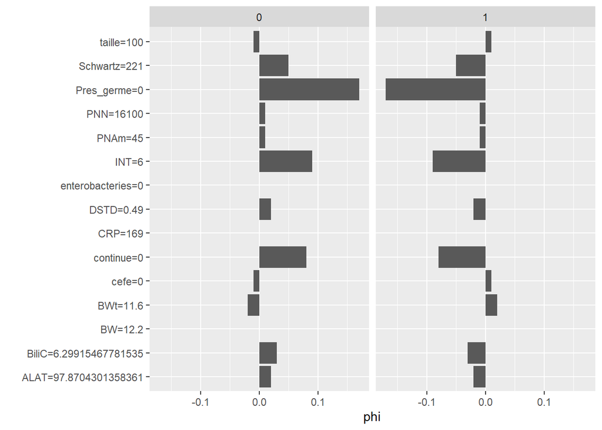

```r
shapley$explain(x.interest = X[2, ])
shapley$plot()
```

```r
head(shapley$results, n=15)
```

```
##            feature class   phi    phi.var          feature.value
## 1             cefe     0 -0.01 0.03020202                 cefe=0
## 2             DSTD     0  0.02 0.01979798              DSTD=0.49
## 3         continue     0  0.08 0.07434343             continue=0
## 4              INT     0  0.09 0.08272727                  INT=6
## 5             PNAm     0  0.01 0.01000000                PNAm=45
## 6           taille     0 -0.01 0.01000000             taille=100
## 7               BW     0  0.00 0.00000000                BW=12.2
## 8              BWt     0 -0.02 0.04000000               BWt=11.6
## 9              CRP     0  0.00 0.04040404                CRP=169
## 10             PNN     0  0.01 0.03020202              PNN=16100
## 11            ALAT     0  0.02 0.04000000  ALAT=97.8704301358361
## 12           BiliC     0  0.03 0.02939394 BiliC=6.29915467781535
## 13        Schwartz     0  0.05 0.06818182           Schwartz=221
## 14      Pres_germe     0  0.17 0.14252525           Pres_germe=0
## 15 enterobacteries     0  0.00 0.00000000      enterobacteries=0
```

### Bilan

Ces travaux ont permis d’interpréter le fonctionnement interne de notre forêt aléatoire, à l’aide du package “IML”.

- Dans un premier temps, nous avons mesurer **l’importance des variables** et nous les avons classer.
- Ensuite nous avons observer **comment ces variables influençaient la prédiction du sous-dosage**, à l’aide des courbes ALE.
- Enfin, avec l’exemple de 2 dosages, **nous avons décortiquer la logique** de notre forêt aléatoire pour voir comment les prédictions s’effectuaient, avec l’aide des SHAP values.